# Scientific Accountability in Shiny Apps

Generating reproducible reports with Shiny apps

January Weiner

Core Unit for Bioinformatics, BIH@Charité

## Reproducibility vs Accountability

In practice, what is reproducible, is not accountable.

## Customization

- Check the `files` folder for alternate background images and logos.
- Some of the changes you can make directly in this qmd file
- Others require you to edit the `cubi.scss` file.

For example, to make the title slide with white background, you can use the `files/title_background_white.svg` file, but you will also have to change the `title`, `subtitle` and `quarto-title-author` colors in the `cubi.scss` file, otherwise they will stay white.

## Multicolumn slide

### Right column title

(adding `.fragment` causes the contents to be displayed in steps)

# Part II separator slide

## Simple numbered and unnumbered lists

- One
- Two
1. One
2. Two

## Incremental list

- Item 1
- Item 2
- Item 3

## Incremental contents

First part

Second part

This is a slide without a title (use the dashes to separate)

## Transitions

Define them in the YAML header or like here, in the slide title.

Types: none, fade, slide, convex, concave, zoom

## Code

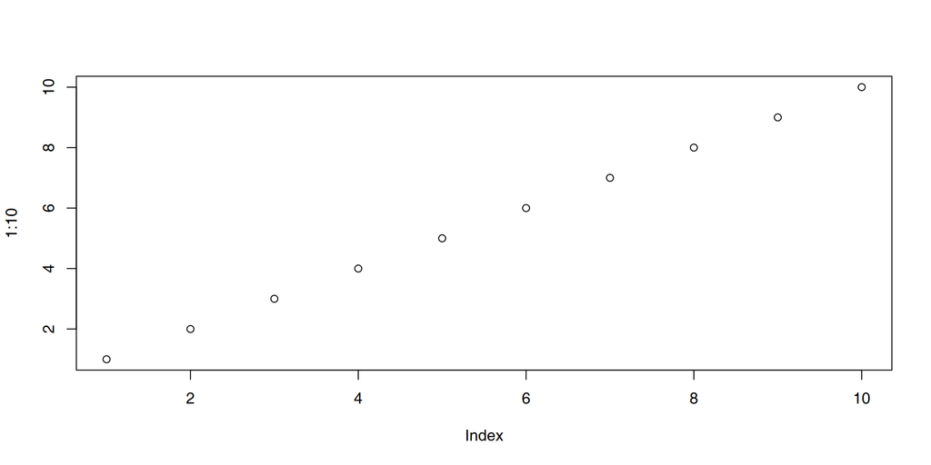

Figure 1: A dumb plot

```r
plot(1:10)
```

**Tip**

Ctrl-click on the image to zoom. And here is a 3.1415927 for you.

## Code

There are many customization options for the code. For example, you can highlight (and even animate) certain lines of code:

```r
a <- rnorm(10)
b <- rnorm(10) + a
c <- a + b * rnorm(10)
```

## Thank you

Acknowledgements

Sources

[figure not shown]